# What’s Cookデータ(決定木モデル構築)

true

2018-09-18

# 分析データ概要

## 学習用データ数 (train.csv)

[1] nSample = 39,774

## 説明変数

[1] “300var_ing0001_salt | ing0002_onions | ing0003_olive.oil | ing0004_water | ing0005_garlic | ing0006_sugar | ing0007_garlic.cloves | ing0008_butter | ing0009_ground.black.pepper | ing0010_all.purpose.flour | ing0011_vegetable.oil | ing0012_pepper | ing0013_eggs | ing0014_soy.sauce | ing0015_kosher.salt | ing0016_green.onions | ing0017_tomatoes | ing0018_large.eggs | ing0019_carrots | ing0020_unsalted.butter | ing0021_ground.cumin | ing0022_extra.virgin.olive.oil | ing0023_black.pepper | ing0024_milk | ing0025_chili.powder | ing0026_oil | ing0027_red.bell.pepper | ing0028_purple.onion | ing0029_scallions | ing0030_grated.parmesan.cheese | ing0031_corn.starch | ing0032_ginger | ing0033_sesame.oil | ing0034_jalapeno.chilies | ing0035_baking.powder | ing0036_dried.oregano | ing0037_chopped.cilantro.fresh | ing0038_fresh.lemon.juice | ing0039_diced.tomatoes | ing0040_minced.garlic | ing0041_fresh.parsley | ing0042_sour.cream | ing0043_chicken.broth | ing0044_cayenne.pepper | ing0045_cooking.spray | ing0046_brown.sugar | ing0047_fresh.ginger | ing0048_shallots | ing0049_lime | ing0050_garlic.powder | ing0051_lemon.juice | ing0052_fresh.lime.juice | ing0053_flour | ing0054_honey | ing0055_vanilla.extract | ing0056_paprika | ing0057_fish.sauce | ing0058_chopped.onion | ing0059_canola.oil | ing0060_lemon | ing0061_ground.cinnamon | ing0062_rice.vinegar | ing0063_avocado | ing0064_dry.white.wine | ing0065_yellow.onion | ing0066_green.bell.pepper | ing0067_heavy.cream | ing0068_tomato.paste | ing0069_cilantro.leaves | ing0070_cilantro | ing0071_fresh.basil | ing0072_white.sugar | ing0073_boneless.skinless.chicken.breasts | ing0074_flat.leaf.parsley | ing0075_lime.juice | ing0076_bay.leaves | ing0077_chicken.stock | ing0078_potatoes | ing0079_chicken | ing0080_corn.tortillas | ing0081_salsa | ing0082_ground.turmeric | ing0083_cumin.seed | ing0084_freshly.ground.pepper | ing0085_cumin | ing0086_garam.masala | ing0087_baking.soda | ing0088_sea.salt | ing0089_shrimp | ing0090_black.beans | ing0091_zucchini | ing0092_large.garlic.cloves | ing0093_dried.thyme | ing0094_buttermilk | ing0095_flour.tortillas | ing0096_tomato.sauce | ing0097_bay.leaf | ing0098_granulated.sugar | ing0099_celery | ing0100_ground.beef | ing0101_coconut.milk | ing0102_fresh.cilantro | ing0103_plum.tomatoes | ing0104_crushed.red.pepper | ing0105_chicken.breasts | ing0106_ground.coriander | ing0107_chopped.cilantro | ing0108_mayonaise | ing0109_whole.milk | ing0110_cucumber | ing0111_green.chilies | ing0112_shredded.cheddar.cheese | ing0113_tumeric | ing0114_red.wine.vinegar | ing0115_white.onion | ing0116_cinnamon | ing0117_curry.powder | ing0118_sesame.seeds | ing0119_worcestershire.sauce | ing0120_ground.ginger | ing0121_hot.sauce | ing0122_red.pepper.flakes | ing0123_red.chili.peppers | ing0124_cinnamon.sticks | ing0125_bacon | ing0126_whipping.cream | ing0127_clove | ing0128_boneless.skinless.chicken.breast.halves | ing0129_peanut.oil | ing0130_ground.nutmeg | ing0131_warm.water | ing0132_peeled.fresh.ginger | ing0133_mushrooms | ing0134_coarse.salt | ing0135_large.egg.yolks | ing0136_celery.ribs | ing0137_dried.basil | ing0138_parmesan.cheese | ing0139_cream.cheese | ing0140_ground.red.pepper | ing0141_balsamic.vinegar | ing0142_white.vinegar | ing0143_egg.yolks | ing0144_capers | ing0145_crushed.red.pepper.flakes | ing0146_onion.powder | ing0147_rice | ing0148_dijon.mustard | ing0149_cold.water | ing0150_mirin | ing0151_eggplant | ing0152_large.egg.whites | ing0153_powdered.sugar | ing0154_fresh.basil.leaves | ing0155_lime.wedges | ing0156_cooking.oil | ing0157_cayenne | ing0158_sliced.green.onions | ing0159_raisins | ing0160_fat.free.less.sodium.chicken.broth | ing0161_beansprouts | ing0162_ground.pork | ing0163_shredded.mozzarella.cheese | ing0164_mozzarella.cheese | ing0165_red.pepper | ing0166_black.peppercorns | ing0167_sauce | ing0168_sweet.potatoes | ing0169_cheese | ing0170_coriander | ing0171_cherry.tomatoes | ing0172_medium.shrimp | ing0173_ketchup | ing0174_cheddar.cheese | ing0175_oyster.sauce | ing0176_leeks | ing0177_crushed.tomatoes | ing0178_egg.whites | ing0179_fresh.mint | ing0180_white.pepper | ing0181_oregano | ing0182_finely.chopped.onion | ing0183_low.sodium.soy.sauce | ing0184_chopped.celery | ing0185_fresh.rosemary | ing0186_large.shrimp | ing0187_hoisin.sauce | ing0188_light.brown.sugar | ing0189_spring.onions | ing0190_cabbage | ing0191_peanuts | ing0192_vegetable.broth | ing0193_cooked.rice | ing0194_cracked.black.pepper | ing0195_confectioners.sugar | ing0196_ground.pepper | ing0197_chickpeas | ing0198_bell.pepper | ing0199_coriander.seeds | ing0200_active.dry.yeast | ing0201_italian.seasoning | ing0202_lean.ground.beef | ing0203_green.pepper | ing0204_low.salt.chicken.broth | ing0205_feta.cheese.crumbles | ing0206_frozen.peas | ing0207_fresh.oregano | ing0208_thyme | ing0209_cajun.seasoning | ing0210_white.wine | ing0211_cornmeal | ing0212_ground.cloves | ing0213_beef.broth | ing0214_plain.yogurt | ing0215_chopped.fresh.thyme | ing0216_lemongrass | ing0217_long.grain.rice | ing0218_boneless.chicken.skinless.thigh | ing0219_spinach | ing0220_orange.juice | ing0221_ground.allspice | ing0222_toasted.sesame.oil | ing0223_ricotta.cheese | ing0224_hot.water | ing0225_white.wine.vinegar | ing0226_boiling.water | ing0227_orange | ing0228_chopped.garlic | ing0229_grated.lemon.zest | ing0230_fennel.seeds | ing0231_parsley | ing0232_fresh.thyme | ing0233_parmigiano.reggiano.cheese | ing0234_pinenuts | ing0235_light.soy.sauce | ing0236_smoked.paprika | ing0237_yellow.corn.meal | ing0238_spaghetti | ing0239_ground.white.pepper | ing0240_sake | ing0241_low.sodium.chicken.broth | ing0242_green.beans | ing0243_fresh.ginger.root | ing0244_sweet.onion | ing0245_half…half | ing0246_chile.pepper | ing0247_chopped.parsley | ing0248_cider.vinegar | ing0249_corn | ing0250_chicken.thighs | ing0251_mustard.seeds | ing0252_vinegar | ing0253_chiles | ing0254_ghee | ing0255_tomatillos | ing0256_pasta | ing0257_basmati.rice | ing0258_shiitake | ing0259_dark.brown.sugar | ing0260_chopped.fresh.mint | ing0261_vanilla | ing0262_hot.pepper.sauce | ing0263_bread.crumbs | ing0264_green.chile | ing0265_shredded.Monterey.Jack.cheese | ing0266_tortilla.chips | ing0267_enchilada.sauce | ing0268_Sriracha | ing0269_serrano.chile | ing0270_dark.soy.sauce | ing0271_cooked.chicken | ing0272_dry.red.wine | ing0273_dry.bread.crumbs | ing0274_toasted.sesame.seeds | ing0275_pork | ing0276_chopped.tomatoes | ing0277_fine.sea.salt | ing0278_arborio.rice | ing0279_garlic.paste | ing0280_fresh.coriander | ing0281_radishes | ing0282_saffron.threads | ing0283_prosciutto | ing0284_romaine.lettuce | ing0285_fresh.mushrooms | ing0286_corn.kernels | ing0287_juice | ing0288_basil | ing0289_yellow.bell.pepper | ing0290_apple.cider.vinegar | ing0291_chopped.pecans | ing0292_fresh.parmesan.cheese | ing0293_long.grain.white.rice | ing0294_creole.seasoning | ing0295_melted.butter | ing0296_mango | ing0297_feta.cheese | ing0298_baguette | ing0299_peaches | ing0300_basil.leaves”

## 学習/テスト用データ分割 (parition training data)

[1] trainDataRatio=0.9

| nTotal | numOfSamping | numOfSampingRatio_output | numOfSampingRatio_input |
| --- | --- | --- | --- |
| 39774 | 35796 | 0.8999849 | 0.9 |

# モデル構築結果

## 樹形図 (Tree diagram)

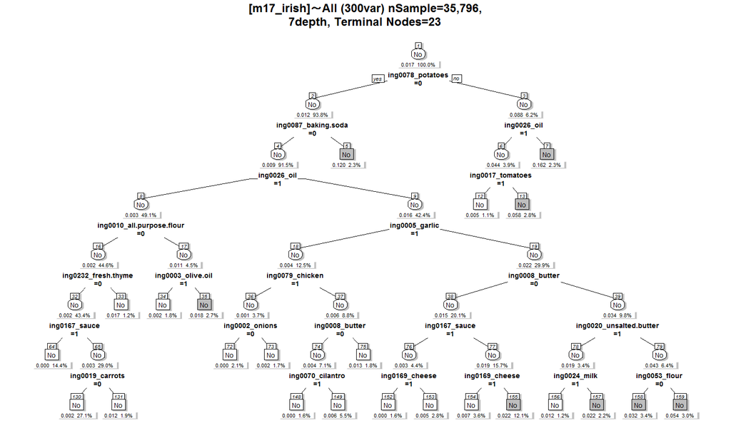

## 決定木ルール抽出 (Each Leaf Rules)

|  | no | node | count | ratio | response | prob | rootProb | lift | depth | rule |
| --- | --- | --- | --- | --- | --- | --- | --- | --- | --- | --- |
| 23 | 1 | 7 | 826 | 0.023 | No | 0.162 | 0.017 | 9.678 | 2 | [ing0078_potatoes=1] &amp; [ing0026_oil=0] |
| 20 | 2 | 5 | 820 | 0.023 | No | 0.12 | 0.017 | 7.13 | 2 | [ing0078_potatoes=0] &amp; [ing0087_baking.soda=1] |
| 22 | 3 | 13 | 1011 | 0.028 | No | 0.058 | 0.017 | 3.482 | 3 | [ing0078_potatoes=1] &amp; [ing0026_oil=1] &amp; [ing0017_tomatoes=0] |
| 19 | 4 | 159 | 1069 | 0.03 | No | 0.054 | 0.017 | 3.237 | 7 | [ing0078_potatoes=0] &amp; [ing0087_baking.soda=0] &amp; [ing0026_oil=0] &amp; [ing0005_garlic=0] &amp; [ing0008_butter=1] &amp; [ing0020_unsalted.butter=0] &amp; [ing0053_flour=1] |
| 18 | 5 | 158 | 1208 | 0.034 | No | 0.032 | 0.017 | 1.926 | 7 | [ing0078_potatoes=0] &amp; [ing0087_baking.soda=0] &amp; [ing0026_oil=0] &amp; [ing0005_garlic=0] &amp; [ing0008_butter=1] &amp; [ing0020_unsalted.butter=0] &amp; [ing0053_flour=0] |
| 17 | 6 | 157 | 801 | 0.022 | No | 0.022 | 0.017 | 1.341 | 7 | [ing0078_potatoes=0] &amp; [ing0087_baking.soda=0] &amp; [ing0026_oil=0] &amp; [ing0005_garlic=0] &amp; [ing0008_butter=1] &amp; [ing0020_unsalted.butter=1] &amp; [ing0024_milk=0] |
| 15 | 7 | 155 | 4327 | 0.121 | No | 0.022 | 0.017 | 1.324 | 7 | [ing0078_potatoes=0] &amp; [ing0087_baking.soda=0] &amp; [ing0026_oil=0] &amp; [ing0005_garlic=0] &amp; [ing0008_butter=0] &amp; [ing0167_sauce=0] &amp; [ing0169_cheese=0] |
| 6 | 8 | 35 | 949 | 0.027 | No | 0.018 | 0.017 | 1.069 | 5 | [ing0078_potatoes=0] &amp; [ing0087_baking.soda=0] &amp; [ing0026_oil=1] &amp; [ing0010_all.purpose.flour=1] &amp; [ing0003_olive.oil=0] |
| 4 | 9 | 33 | 421 | 0.012 | No | 0.017 | 0.017 | 0.992 | 5 | [ing0078_potatoes=0] &amp; [ing0087_baking.soda=0] &amp; [ing0026_oil=1] &amp; [ing0010_all.purpose.flour=0] &amp; [ing0232_fresh.thyme=1] |
| 11 | 10 | 75 | 635 | 0.018 | No | 0.013 | 0.017 | 0.752 | 6 | [ing0078_potatoes=0] &amp; [ing0087_baking.soda=0] &amp; [ing0026_oil=0] &amp; [ing0005_garlic=1] &amp; [ing0079_chicken=0] &amp; [ing0008_butter=1] |

[output cut: 13 more lines]

# 変数重要度 (Variable Importance)

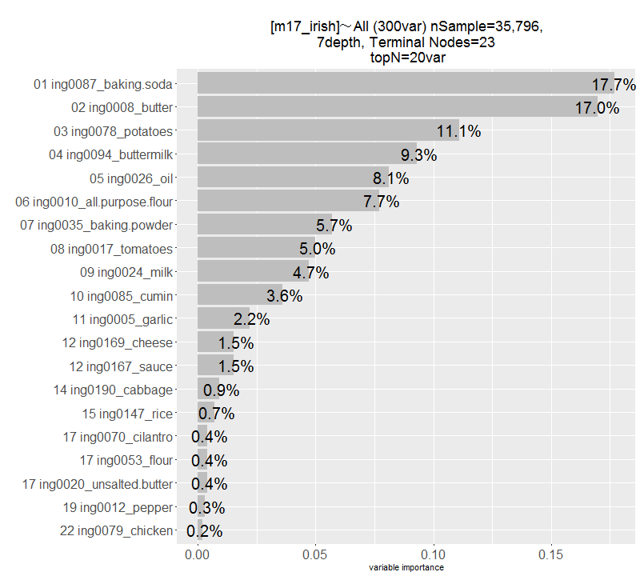

# モデル評価

## 混同行列 (Confusion Matrix)

train data

|  | No | Yes |
| --- | --- | --- |
| No | 35196 | 600 |
| Yes | 0 | 0 |

vaild data

|  | No | Yes |
| --- | --- | --- |
| No | 3911 | 67 |
| Yes | 0 | 0 |

## 正解率 (Accuracy)

Accuracy

|  | Accuracy_train | Accuracy_valid | Accuracy_diff |
| --- | --- | --- | --- |
| Accuracy | 0.9832 | 0.9832 | 1e-04 |

## モデル評価 (AUC)

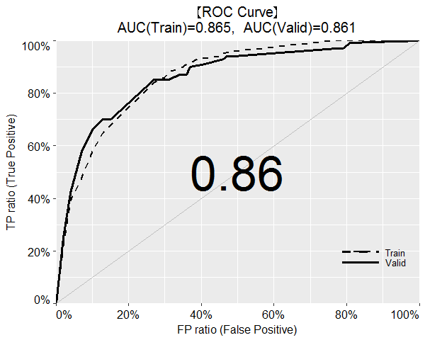